# Ford GoBike Data Exploration

## Preliminary Wrangling

This notebook explores a dataset containing information about Ford's GoBike program for San Francisco area from june 2017 to April 2019 .The dataset is available through https://s3.amazonaws.com/fordgobike-data/index.html

```python
# import all packages and set plots to be embedded inline
import numpy as np
import pandas as pd
import matplotlib.pyplot as plt
import seaborn as sb
import os
import calendar
from matplotlib.ticker import ScalarFormatter

%matplotlib inline
```

> Load in your dataset and describe its properties through the questions below. Try and motivate your exploration goals through this section.

```python
%config IPCompleter.greedy=True
```

```python
# Build Dataset file

path = "D:/Data_UdacityProject3/"
files = os.listdir(path)
bike_dataset = []
print ("Preparing the Dataset")
for file in files:
    #print(text_file)
    filename = path+file
    print(filename)
    df = pd.read_csv(filename)
    bike_dataset.append(df)
bike_df = pd.concat(bike_dataset)
alldatasetfile="D:/Data_UdacityProject3/alldataset.csv"
if os.path.isfile(alldatasetfile):
    print ("File exist")
else:
    print ("File not exist")
    bike_df.to_csv (r'D:/Data_UdacityProject3/alldataset.csv', index = False)
```

```
Preparing the Dataset
D:/Data_UdacityProject3/2017-fordgobike-tripdata.csv
D:/Data_UdacityProject3/201801-fordgobike-tripdata.csv
D:/Data_UdacityProject3/201802-fordgobike-tripdata.csv
D:/Data_UdacityProject3/201803-fordgobike-tripdata.csv
D:/Data_UdacityProject3/201804-fordgobike-tripdata.csv
D:/Data_UdacityProject3/201805-fordgobike-tripdata.csv
D:/Data_UdacityProject3/201806-fordgobike-tripdata.csv
D:/Data_UdacityProject3/201807-fordgobike-tripdata.csv
D:/Data_UdacityProject3/201808-fordgobike-tripdata.csv
D:/Data_UdacityProject3/201809-fordgobike-tripdata.csv
D:/Data_UdacityProject3/201810-fordgobike-tripdata.csv
D:/Data_UdacityProject3/201811-fordgobike-tripdata.csv
D:/Data_UdacityProject3/201812-fordgobike-tripdata.csv
D:/Data_UdacityProject3/201901-fordgobike-tripdata.csv
D:/Data_UdacityProject3/201902-fordgobike-tripdata.csv
D:/Data_UdacityProject3/201903-fordgobike-tripdata.csv
D:/Data_UdacityProject3/201904-fordgobike-tripdata.csv
File not exist
```

```python
 # load  the dataset into dataframe
df_gobikeford = pd.read_csv('D:/Data_UdacityProject3/alldataset.csv')
df_gobikeford.shape
```

```
(3254325, 16)
```

```python
df_gobikeford.head()
```

|  | duration_sec | start_time | end_time | start_station_id | start_station_name | start_station_latitude | start_station_longitude | end_station_id | end_station_name | end_station_latitude | end_station_longitude | bike_id | user_type | member_birth_year | member_gender | bike_share_for_all_trip |
| --- | --- | --- | --- | --- | --- | --- | --- | --- | --- | --- | --- | --- | --- | --- | --- | --- |
| 0 | 80110 | 2017-12-31 16:57:39.6540 | 2018-01-01 15:12:50.2450 | 74.0 | Laguna St at Hayes St | 37.776435 | -122.426244 | 43.0 | San Francisco Public Library (Grove St at Hyde... | 37.778768 | -122.415929 | 96 | Customer | 1987.0 | Male | NaN |
| 1 | 78800 | 2017-12-31 15:56:34.8420 | 2018-01-01 13:49:55.6170 | 284.0 | Yerba Buena Center for the Arts (Howard St at ... | 37.784872 | -122.400876 | 96.0 | Dolores St at 15th St | 37.766210 | -122.426614 | 88 | Customer | 1965.0 | Female | NaN |
| 2 | 45768 | 2017-12-31 22:45:48.4110 | 2018-01-01 11:28:36.8830 | 245.0 | Downtown Berkeley BART | 37.870348 | -122.267764 | 245.0 | Downtown Berkeley BART | 37.870348 | -122.267764 | 1094 | Customer | NaN | NaN | NaN |
| 3 | 62172 | 2017-12-31 17:31:10.6360 | 2018-01-01 10:47:23.5310 | 60.0 | 8th St at Ringold St | 37.774520 | -122.409449 | 5.0 | Powell St BART Station (Market St at 5th St) | 37.783899 | -122.408445 | 2831 | Customer | NaN | NaN | NaN |
| 4 | 43603 | 2017-12-31 14:23:14.0010 | 2018-01-01 02:29:57.5710 | 239.0 | Bancroft Way at Telegraph Ave | 37.868813 | -122.258764 | 247.0 | Fulton St at Bancroft Way | 37.867789 | -122.265896 | 3167 | Subscriber | 1997.0 | Female | NaN |

```python
df_gobikeford.columns
```

```
Index(['duration_sec', 'start_time', 'end_time', 'start_station_id',
       'start_station_name', 'start_station_latitude',
       'start_station_longitude', 'end_station_id', 'end_station_name',
       'end_station_latitude', 'end_station_longitude', 'bike_id', 'user_type',
       'member_birth_year', 'member_gender', 'bike_share_for_all_trip'],
      dtype='object')
```

```python
df_gobikeford.info()
```

```
<class 'pandas.core.frame.DataFrame'>
RangeIndex: 3254325 entries, 0 to 3254324
Data columns (total 16 columns):
 #   Column                   Dtype
---  ------                   -----
 0   duration_sec             int64
 1   start_time               object
 2   end_time                 object
 3   start_station_id         float64
 4   start_station_name       object
 5   start_station_latitude   float64
 6   start_station_longitude  float64
 7   end_station_id           float64
 8   end_station_name         object
 9   end_station_latitude     float64
 10  end_station_longitude    float64
 11  bike_id                  int64
 12  user_type                object
 13  member_birth_year        float64
 14  member_gender            object
 15  bike_share_for_all_trip  object
dtypes: float64(7), int64(2), object(7)
memory usage: 397.3+ MB
```

```python
#Convert time variables from string to datetime
df_gobikeford['start_time'] = pd.to_datetime(df_gobikeford['start_time'])
df_gobikeford['end_time'] = pd.to_datetime(df_gobikeford['end_time'])
```

```python
#Get day , month  and year From start_time

df_gobikeford['day'] = df_gobikeford['start_time'].dt.day
df_gobikeford['month'] = df_gobikeford['start_time'].dt.month
df_gobikeford['year'] = df_gobikeford['start_time'].dt.year
df_gobikeford['day_name'] = df_gobikeford['start_time'].dt.day_name()
df_gobikeford['month_name'] = df_gobikeford['start_time'].dt.month_name()
df_gobikeford.head(2)
```

|  | duration_sec | start_time | end_time | start_station_id | start_station_name | start_station_latitude | start_station_longitude | end_station_id | end_station_name | end_station_latitude | ... | bike_id | user_type | member_birth_year | member_gender | bike_share_for_all_trip | day | month | year | day_name | month_name |
| --- | --- | --- | --- | --- | --- | --- | --- | --- | --- | --- | --- | --- | --- | --- | --- | --- | --- | --- | --- | --- | --- |
| 0 | 80110 | 2017-12-31 16:57:39.654 | 2018-01-01 15:12:50.245 | 74.0 | Laguna St at Hayes St | 37.776435 | -122.426244 | 43.0 | San Francisco Public Library (Grove St at Hyde... | 37.778768 | ... | 96 | Customer | 1987.0 | Male | NaN | 31 | 12 | 2017 | Sunday | December |
| 1 | 78800 | 2017-12-31 15:56:34.842 | 2018-01-01 13:49:55.617 | 284.0 | Yerba Buena Center for the Arts (Howard St at ... | 37.784872 | -122.400876 | 96.0 | Dolores St at 15th St | 37.766210 | ... | 88 | Customer | 1965.0 | Female | NaN | 31 | 12 | 2017 | Sunday | December |

2 rows × 21 columns

```python
# Get start hour as 12 format
df_gobikeford['start-hour'] = pd.to_datetime(df_gobikeford['start_time']).dt.strftime('%I %p').tolist()
df_gobikeford['hour'] = pd.to_datetime(df_gobikeford['start_time']).dt.hour
df_gobikeford.head(2)
```

|  | duration_sec | start_time | end_time | start_station_id | start_station_name | start_station_latitude | start_station_longitude | end_station_id | end_station_name | end_station_latitude | ... | member_birth_year | member_gender | bike_share_for_all_trip | day | month | year | day_name | month_name | start-hour | hour |
| --- | --- | --- | --- | --- | --- | --- | --- | --- | --- | --- | --- | --- | --- | --- | --- | --- | --- | --- | --- | --- | --- |
| 0 | 80110 | 2017-12-31 16:57:39.654 | 2018-01-01 15:12:50.245 | 74.0 | Laguna St at Hayes St | 37.776435 | -122.426244 | 43.0 | San Francisco Public Library (Grove St at Hyde... | 37.778768 | ... | 1987.0 | Male | NaN | 31 | 12 | 2017 | Sunday | December | 04 PM | 16 |
| 1 | 78800 | 2017-12-31 15:56:34.842 | 2018-01-01 13:49:55.617 | 284.0 | Yerba Buena Center for the Arts (Howard St at ... | 37.784872 | -122.400876 | 96.0 | Dolores St at 15th St | 37.766210 | ... | 1965.0 | Female | NaN | 31 | 12 | 2017 | Sunday | December | 03 PM | 15 |

2 rows × 23 columns

```python
# Get members age
df_gobikeford['member_age'] = df_gobikeford['member_birth_year'].apply(lambda x: 2020 - x)
df_gobikeford.head()
```

|  | duration_sec | start_time | end_time | start_station_id | start_station_name | start_station_latitude | start_station_longitude | end_station_id | end_station_name | end_station_latitude | ... | member_gender | bike_share_for_all_trip | day | month | year | day_name | month_name | start-hour | hour | member_age |
| --- | --- | --- | --- | --- | --- | --- | --- | --- | --- | --- | --- | --- | --- | --- | --- | --- | --- | --- | --- | --- | --- |
| 0 | 80110 | 2017-12-31 16:57:39.654 | 2018-01-01 15:12:50.245 | 74.0 | Laguna St at Hayes St | 37.776435 | -122.426244 | 43.0 | San Francisco Public Library (Grove St at Hyde... | 37.778768 | ... | Male | NaN | 31 | 12 | 2017 | Sunday | December | 04 PM | 16 | 33.0 |
| 1 | 78800 | 2017-12-31 15:56:34.842 | 2018-01-01 13:49:55.617 | 284.0 | Yerba Buena Center for the Arts (Howard St at ... | 37.784872 | -122.400876 | 96.0 | Dolores St at 15th St | 37.766210 | ... | Female | NaN | 31 | 12 | 2017 | Sunday | December | 03 PM | 15 | 55.0 |
| 2 | 45768 | 2017-12-31 22:45:48.411 | 2018-01-01 11:28:36.883 | 245.0 | Downtown Berkeley BART | 37.870348 | -122.267764 | 245.0 | Downtown Berkeley BART | 37.870348 | ... | NaN | NaN | 31 | 12 | 2017 | Sunday | December | 10 PM | 22 | NaN |
| 3 | 62172 | 2017-12-31 17:31:10.636 | 2018-01-01 10:47:23.531 | 60.0 | 8th St at Ringold St | 37.774520 | -122.409449 | 5.0 | Powell St BART Station (Market St at 5th St) | 37.783899 | ... | NaN | NaN | 31 | 12 | 2017 | Sunday | December | 05 PM | 17 | NaN |
| 4 | 43603 | 2017-12-31 14:23:14.001 | 2018-01-01 02:29:57.571 | 239.0 | Bancroft Way at Telegraph Ave | 37.868813 | -122.258764 | 247.0 | Fulton St at Bancroft Way | 37.867789 | ... | Female | NaN | 31 | 12 | 2017 | Sunday | December | 02 PM | 14 | 23.0 |

5 rows × 24 columns

```python
#Remve null value to convert to int
df_gobikeford[df_gobikeford['start_station_id'].isna()]
df_gobikeford.dropna(subset=['start_station_id'],inplace=True)
```

```python
# Convert the start station id  and end station id to int
df_gobikeford['start_station_id']=df_gobikeford['start_station_id'].astype(int)
df_gobikeford['end_station_id']=df_gobikeford['end_station_id'].astype(int)
```

```python
df_gobikeford.shape
```

```
(3241824, 24)
```

```python
df_gobikeford = df_gobikeford[df_gobikeford['member_age']<= 100]
```

```python
df_gobikeford.shape
```

```
(3022079, 24)
```

### What is the structure of your dataset?

The dataset consist of 3254325 rides data from june 2017 to April 2019 with 16 features ( duration_sec ,start_time ,end_time ,start_station_id ,start_station_name ,start_station_latitude ,start_station_longitude ,end_station_id ,end_station_name ,end_station_latitude ,end_station_longitude ,bike_id, user_type ,member_birth_year,member_gender and bike_share_for_all_trip)

### What is/are the main feature(s) of interest in your dataset?

I'm mostly interested in figuring out the features (gender, age, user_type) of the riders and the duration of the trips.

### What features in the dataset do you think will help support your investigation into your feature(s) of interest?

I expect that days of the week have effection on rides duration as holidays have mush time compared to working days also months of the year affect on trip duration as weather tempreature affect on riders. I think age of the riders may also affect on trip duration .As well, subscriber users are expected to have more interest than customer users . The affect of the gender on trip is hardly to be expected .

## Univariate Exploration

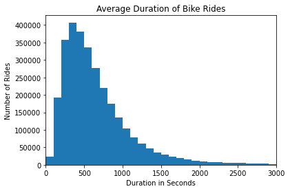

```python
# plot the distribution of trip durations.
duration_bins = np.arange(0, df_gobikeford['duration_sec'].max() + 100, 100)
plt.hist(data = df_gobikeford, x = 'duration_sec', bins = duration_bins)
plt.xlim(0, 3000);
plt.title('Average Duration of Bike Rides', fontsize = 12)
plt.xlabel('Duration in Seconds')
plt.ylabel('Number of Rides')
plt.show()
```

It's right-skewed distribution so we need to apply logarithmic transform to the data .

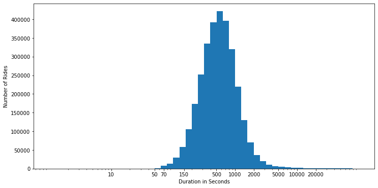

```python
# Trip duration distribution in log scale
log_binsize = 0.1
bins = 10 ** np.arange(0, np.log10(df_gobikeford['duration_sec'].astype(float).max())+log_binsize, log_binsize)
ticks=([10,50,70,150,500,1000,2000,5000,10000,20000])
plt.figure(figsize=[12, 6])
ax=plt.hist(data = df_gobikeford, x = 'duration_sec', bins = bins)
plt.xscale('log')
labels = ['{}'.format(v) for v in ticks]
plt.xticks(ticks,labels)
plt.xlabel('Duration in Seconds')
plt.ylabel('Number of Rides')
plt.show()
```

After applying apply logarithmic transform it's clear that duriation falls in ( 200 - 2000) seconds range but the peak point = 500 second ~ 8 minute around.

```python
#df_gobikeford['user_type']
df_gobikeford["user_type"].value_counts(dropna=False)
```

```
Subscriber    2679791
Customer       342288
Name: user_type, dtype: int64
```

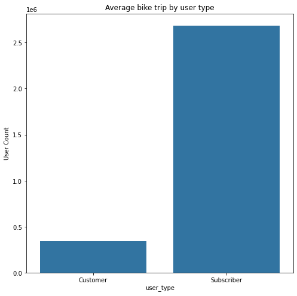

```python
# Type of users (subcriber-customer)
plt.figure(figsize=(8,8))
base_color = sb.color_palette()[0]
sb.countplot(data=df_gobikeford,x='user_type', color = base_color)
plt.ylabel('User Count')
plt.title('Average bike trip by user type')
plt.show()
```

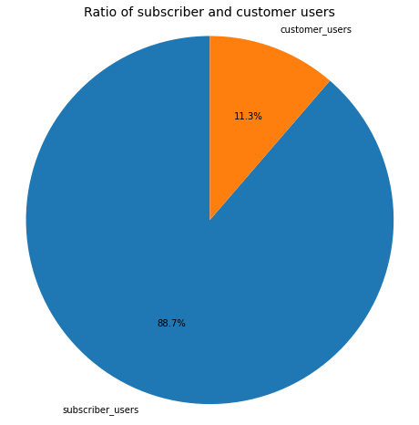

```python
# Ratio of users type (subcriber-customer)
plt.figure(figsize = (8, 8))
subscriber_users=df_gobikeford[df_gobikeford.user_type =='Subscriber'].user_type.count()
customer_users=df_gobikeford[df_gobikeford.user_type =='Customer'].user_type.count()
total_users=df_gobikeford.user_type.count()

plt.pie([subscriber_users/total_users*100,customer_users/total_users*100] ,startangle=90,autopct='%1.1f%%',labels=['subscriber_users','customer_users']);
plt.axis('equal');
plt.title('Ratio of subscriber and customer users', fontsize = 14)
plt.show()
```

From the two figures the number of subscriber users are higher than customer users as the ratio of subscriber users= 88.7% and customer users=11.3%

```python
df_gobikeford["member_gender"].value_counts(dropna=False)
```

```
Male      2240949
Female     731890
Other       49240
Name: member_gender, dtype: int64
```

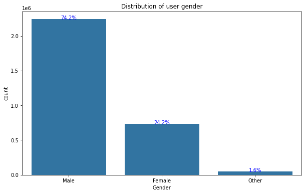

```python
# plot distribution of gender
plt.figure(figsize=[10, 6])
base_color = sb.color_palette()[0]
gender_order = df_gobikeford['member_gender'].value_counts().index
sb.countplot(data = df_gobikeford, x = 'member_gender', color = base_color, order=gender_order)
plt.title('Distribution of user gender')
plt.xlabel('Gender')
# plot gender precent on the bar chart
total_gender=df_gobikeford['member_gender'].count()
gender_counts = df_gobikeford['member_gender'].value_counts()
locs, labels = plt.xticks()
for loc, label in zip(locs, labels):
    gender_number = gender_counts[label.get_text()]
    pct_string = '{:0.1f}%'.format(gender_number/total_gender*100)
    plt.text(loc, gender_number-8, pct_string, ha='center', color='b')

plt.show()
```

```python
df_gobikeford['member_age'].mean()
```

```
36.82837113126427
```

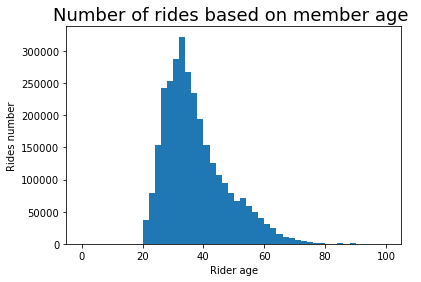

```python
# Plot age distribution
bins = np.arange(0, df_gobikeford['member_age'].max()+2, 2)
plt.hist(data = df_gobikeford, x = 'member_age', bins = bins);
plt.title('Number of rides based on member age ', fontsize = 18);
plt.xlabel('Rider age');
plt.ylabel('Rides number');
plt.show()
```

Ages range from 20 to 70 although there are some outlier may be wrong.

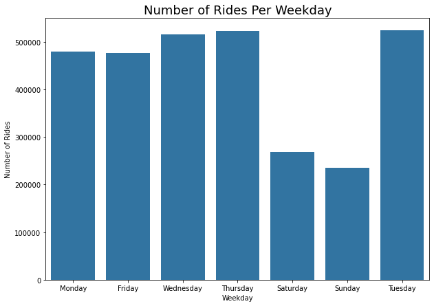

```python
#Plot Number of Rides per Day
plt.figure(figsize = (10, 7))
base_color = sb.color_palette()[0]
sb.countplot(data = df_gobikeford.sort_values(by='day'), x = 'day_name', color = base_color);
plt.title('Number of Rides Per Weekday', fontsize = 18);
plt.ylabel('Number of Rides')
plt.xlabel('Weekday')
plt.show()
```

Sunday and Saturday have less number of trips (weekend) compared to weekdays.Need more investigation to check if user type affect the distribution or not.

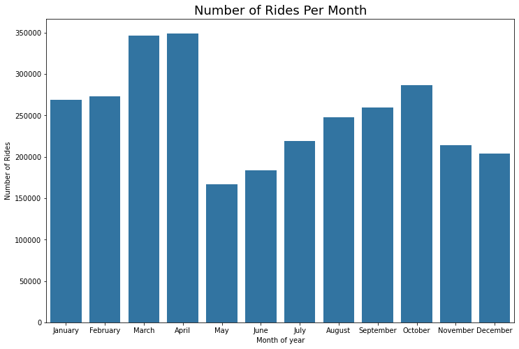

```python
#Plot Number of Rides per month
plt.figure(figsize = (12, 8))
base_color = sb.color_palette()[0]
sb.countplot(data = df_gobikeford.sort_values(by='month'), x = 'month_name', color = base_color);
plt.title('Number of Rides Per Month', fontsize = 18);
plt.ylabel('Number of Rides')
plt.xlabel('Month of year')
plt.show()
```

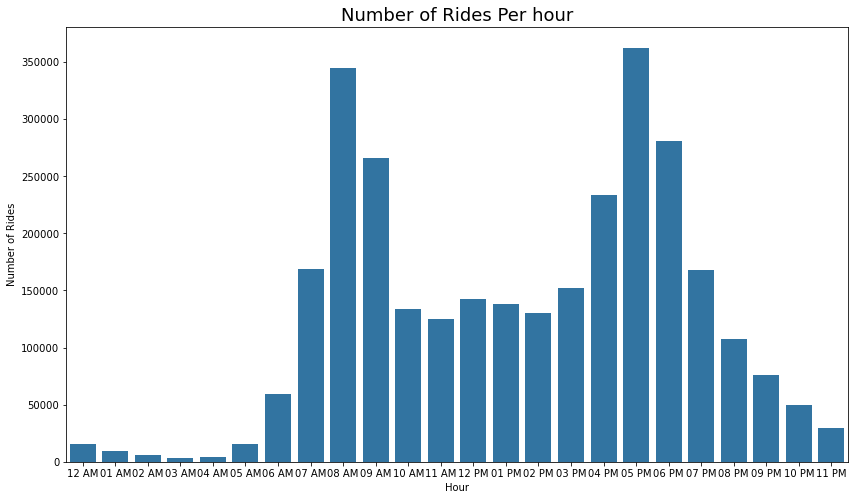

```python
#Plot Number of Rides per month
plt.figure(figsize = (14, 8))
base_color = sb.color_palette()[0]
sb.countplot(data = df_gobikeford.sort_values(by='hour'), x = 'start-hour', color = base_color);
plt.title('Number of Rides Per hour', fontsize = 18);
plt.ylabel('Number of Rides')
plt.xlabel('Hour')
plt.show()
```

The Peak hours fall between(8am to 6pm) .This period is considered the working hours duration.

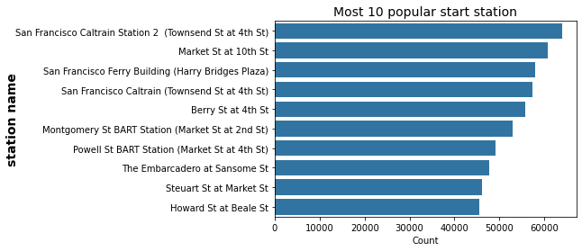

```python
#plot most 10 popular start station
sorted_counts=df_gobikeford['start_station_name'].value_counts().index[:10]
sb.countplot(data = df_gobikeford, y='start_station_name' ,order=sorted_counts, color= base_color  )
plt.title('Most 10 popular start station', fontsize = 14)
plt.ylabel('station name', fontsize = 14,va='center_baseline',weight='bold')
plt.xlabel('Count')
```

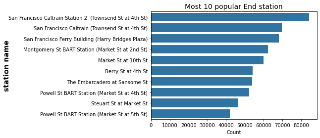

```python
#plot most 10 popular end station
sorted_counts=df_gobikeford['end_station_name'].value_counts().index[:10]
sb.countplot(data = df_gobikeford, y='end_station_name' ,order=sorted_counts, color= base_color);
plt.title('Most 10 popular start station', fontsize = 14)
plt.ylabel('station name', fontsize = 14,va='center_baseline',weight='bold')
plt.title('Most 10 popular End station', fontsize = 14)
plt.xlabel('Count')
```

We can see that the most commonly station used either to start or to end the trip are: -San francisco ferry buliding  
-San francisco caltrain  
-Market st at 10th st

### Discuss the distribution(s) of your variable(s) of interest. Were there any unusual points? Did you need to perform any transformations?

Trip durations have a large range of values with right-skewed distribution , so I explored the data using a log transform. After applying apply logarithmic transform it appeared as unimodal with peak point = 500 second ~ 8 minute around

### Of the features you investigated, were there any unusual distributions? Did you perform any operations on the data to tidy, adjust, or change the form of the data? If so, why did you do this?

I added new variables: day,month,year,hour, age from existing variabes. Only deal with age <= 100 to be more reliable as the max age 114 and I think it is wrong.

## Bivariate Exploration

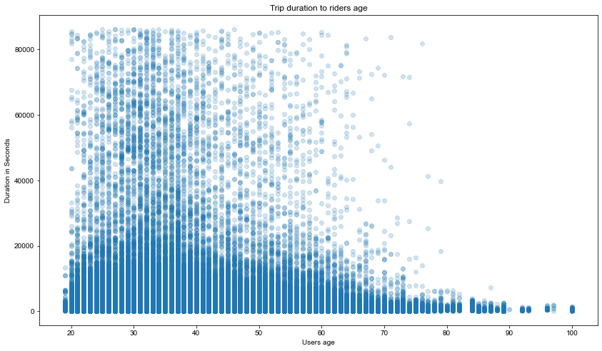

```python
#plot The relationship between age and trip duration
plt.figure(figsize = (14, 8))
plt.scatter(data = df_gobikeford, x = 'member_age', y = 'duration_sec', alpha = 0.2);
plt.style.use('seaborn')
plt.title('Trip duration to riders age');
plt.xlabel('Users age');
plt.ylabel('Duration in Seconds');
```

The visualization is right-skewed, so younger riders tend to take the longest rides.But it is very interesting age from [50-60] have long rides.

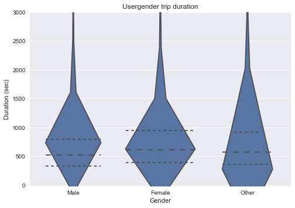

```python
# plot relationship between gender and duration
base_color = sb.color_palette()[0]
sb.violinplot(data=df_gobikeford, x='member_gender', y='duration_sec', color=base_color, inner='quartile')
plt.ylim([-20, 3000])
plt.xlabel('Gender')
plt.ylabel('Duration (sec)')
plt.title('Usergender trip duration');
```

Although the male users number are high than female and others but female and other users have longer trip duration than males.

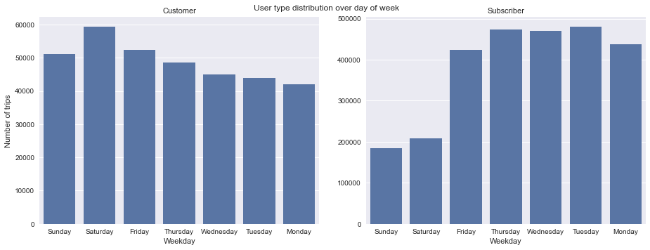

```python
#plot User type distribution over day of the week
g = sb.catplot(data=df_gobikeford, x='day_name', col="user_type",sharey = False, kind='count',color = base_color)
g.fig.set_figwidth(13)
g.set_axis_labels("Weekday", "Number of trips")
g.set_titles("{col_name}")
g.fig.suptitle('User type distribution over day of week', fontsize=12)
```

Subscribers usage distributed on Monday to Friday, although the most of customers usage on the weekends.

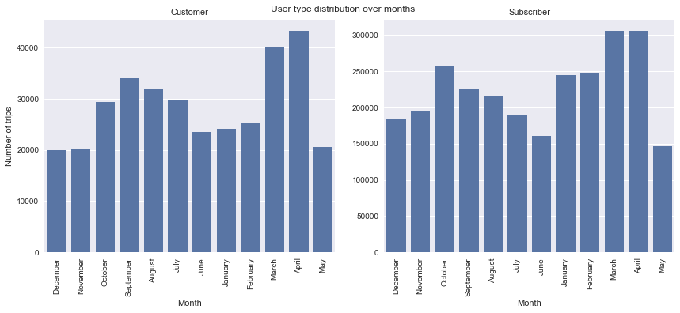

```python
#plot User type distribution over months
g = sb.catplot(data=df_gobikeford, x='month_name', col="user_type",sharey = False,  kind='count',color = base_color)
g.fig.set_figwidth(12)
g.set_axis_labels("Month", "Number of trips")
g.set_titles("{col_name}")
g.fig.suptitle('User type distribution over months', fontsize=12)
g.set_xticklabels(rotation=90);
```

Both subscribers and customers almost have the same monthly usage distribution.

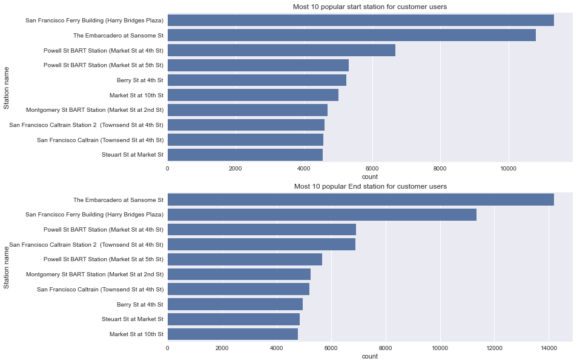

```python
#Plot most 10 start stations for customer users
fig,ax=plt.subplots(2,1,figsize=[12,10])

sorted_counts=df_gobikeford.query('user_type == "Customer"').start_station_name.value_counts().index[:10]
sb.countplot(data = df_gobikeford.query('user_type == "Customer"'),y='start_station_name' ,order=sorted_counts, color= base_color ,ax=ax[0] ) ;

sorted_counts=df_gobikeford.query('user_type=="Customer"').end_station_name.value_counts().index[:10]
sb.countplot(data = df_gobikeford.query('user_type=="Customer"'), y='end_station_name' ,order=sorted_counts, color= base_color ,ax=ax[1]);

plt.sca(ax[0])
plt.title('Most 10 popular start station for customer users', fontsize = 12)
plt.ylabel('Station name', fontsize = 12,va='center_baseline')
#plt.xticks(rotation=90)

plt.sca(ax[1])
plt.ylabel('Station name', fontsize = 12,va='center_baseline')
plt.title('Most 10 popular End station for customer users', fontsize = 12)
#plt.xticks(rotation=90)
```

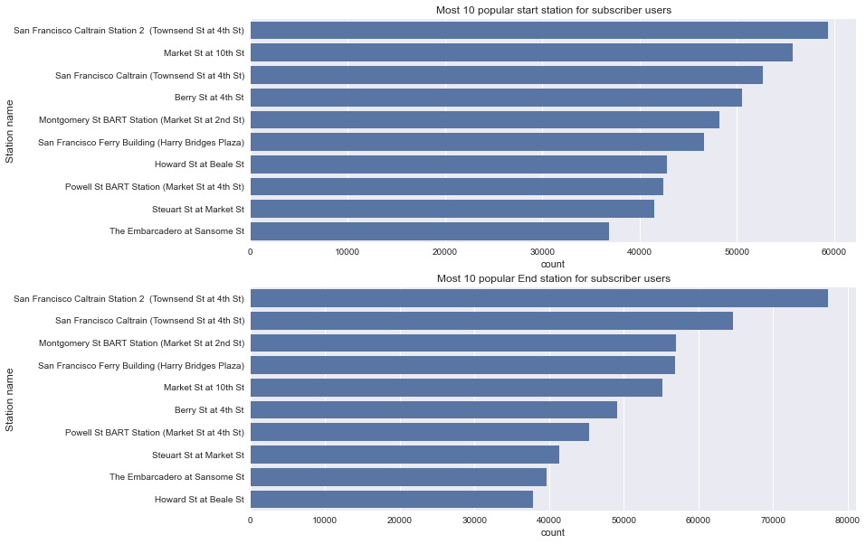

```python
#Plot most 10 start stations for subscriber  users
fig,ax=plt.subplots(nrows=2,ncols=1,figsize=[12,10])

sorted_counts=df_gobikeford.query('user_type == "Subscriber"').start_station_name.value_counts().index[:10]
sb.countplot(data = df_gobikeford.query('user_type == "Subscriber"'),y='start_station_name' ,order=sorted_counts, color= base_color ,ax=ax[0] ) ;

sorted_counts=df_gobikeford.query('user_type =="Subscriber"').end_station_name.value_counts().index[:10]
sb.countplot(data = df_gobikeford.query('user_type =="Subscriber"'), y='end_station_name' ,order=sorted_counts, color= base_color ,ax=ax[1]);

plt.sca(ax[0])
plt.title('Most 10 popular start station for subscriber users', fontsize = 12)
plt.ylabel('Station name', fontsize = 12,va='center_baseline')
#plt.xticks(rotation=90)

plt.sca(ax[1])
plt.ylabel('Station name', fontsize = 12,va='center_baseline')
plt.title('Most 10 popular End station for subscriber users', fontsize = 12)
```

It appears that, subscribers are more than customers in each (start,end) stations. Even so, there are more customers at San Francisco Ferry Building (Harry Bridges Plaza) as start station and The Embarcadero at Sansome St station as end station than other (start,end) statio.

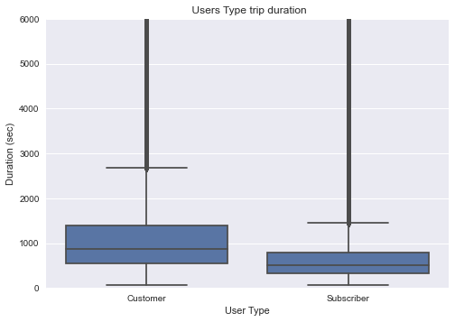

```python
# plot relationship between user type and duration
base_color = sb.color_palette()[0]
sb.boxplot(data=df_gobikeford, x='user_type', y='duration_sec', color=base_color)
plt.ylim([-10, 6000])
plt.xlabel('User Type')
plt.ylabel('Duration (sec)')
plt.title(' Users Type trip duration')
```

Subscriber users trip duration less than customer users trip duration.

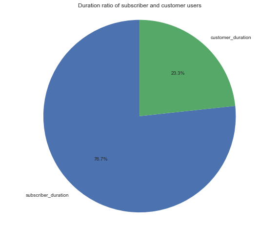

```python
#plot duration ratio to user type
plt.figure(figsize = (10, 8))
subscriber_duration=df_gobikeford[df_gobikeford.user_type =='Subscriber'].duration_sec.sum()
customer_duration=df_gobikeford[df_gobikeford.user_type =='Customer'].duration_sec.sum()
total_duration=df_gobikeford.duration_sec.sum()

plt.pie([subscriber_duration/total_duration*100,customer_duration/total_duration*100] ,startangle=90,autopct='%1.1f%%',labels=['subscriber_duration','customer_duration']);
plt.axis('equal');
plt.title('Duration ratio of subscriber and customer users', fontsize = 12)
plt.show()
```

However customer users percentage are only 11.3% but they shared 23.3% from total trip durations and this considers high ratio compared to their ratio of total users.

### Talk about some of the relationships you observed in this part of the investigation. How did the feature(s) of interest vary with other features in the dataset?

Most of riders age falls between 20 and 40 years old and young users had long trip duration. Female and other users have longer trip duration than males. There is different usage behavior between subscribers and customers. Customers ride more on the weekends, although subscribers usage among a Monday-Friday mainly.For customers there are some stations like San Francisco Ferry Building (Harry Bridges Plaza) and The Embarcadero at Sansome St stations have more trips compared to others.Customer users had high trip duration ratio compared to their participation ratio </p>

### Did you observe any interesting relationships between the other features (not the main feature(s) of interest)?

The variation in trip duration for users older than 50 years old.

## Multivariate Exploration

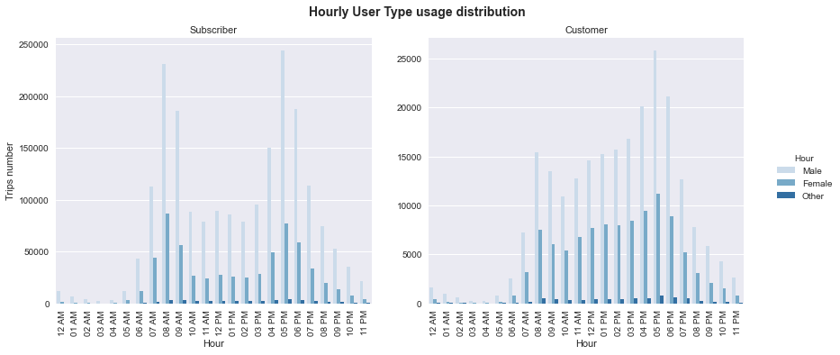

```python
g = sb.catplot(data=df_gobikeford.sort_values(by='hour'), x='start-hour', col="user_type", hue='member_gender', kind='count', sharey = False,palette='Blues')
g.fig.set_figwidth(13)
g.set_axis_labels("Hour", "Trips number")
g._legend.set_title('Hour')
g.set_titles("{col_name}")
g.fig.suptitle('Hourly User Type usage distribution', y=1.03, fontsize=14, fontweight='semibold');
g.set_xticklabels(rotation=90);
```

For all subscribers users gander the heighest trip rate fall between 8am and 6pm that may be related to working hours althought cutomer users rate distarbued among day hours with high rate at 5pm for customers user gender.

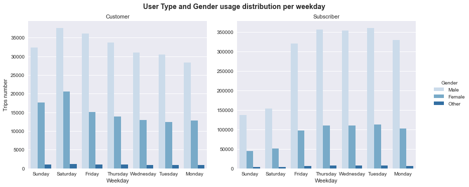

```python
g = sb.catplot(data=df_gobikeford, x='day_name', col="user_type", hue='member_gender', kind='count', sharey = False,palette='Blues')
g.fig.set_figwidth(13)
g.set_axis_labels("Weekday", "Trips number")
g._legend.set_title('Gender')
g.set_titles("{col_name}")
g.fig.suptitle(' User Type and Gender usage distribution per weekday', y=1.03, fontsize=14, fontweight='semibold');
```

While the numbers of males higher than females and others, the usage between customers and subscribers of each gender is almost similar.Female customers littel bit greater than female subscribers. All genders of customers usage are more on the weekends, while subscribers usage during the week.

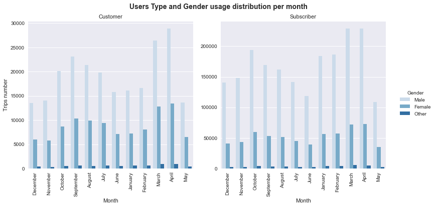

```python
g = sb.catplot(data=df_gobikeford, x='month_name', col="user_type", hue='member_gender', kind='count', sharey = False,palette='Blues')
g.fig.set_figwidth(12)
g.set_axis_labels("Month", "Trips number")
g._legend.set_title('Gender')
g.set_titles("{col_name}")
g.fig.suptitle(' Users Type and Gender usage distribution per month', y=1.03, fontsize=14, fontweight='semibold');
g.set_xticklabels(rotation=90);
```

Both customers and subscribers of each gender are almost have similar distribution.

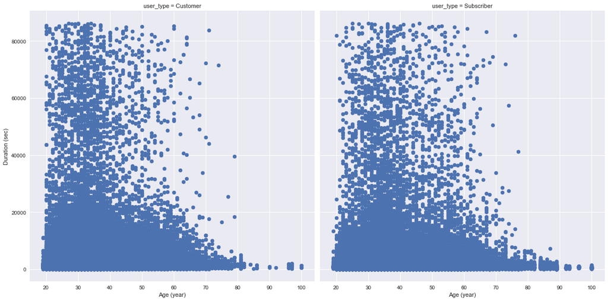

```python
plt.figure(figsize = [12,8])
user_types = sb.FacetGrid(data = df_gobikeford, col = 'user_type', col_wrap = 2, height = 8)
user_types.map(plt.scatter, 'member_age', 'duration_sec')
user_types.set_xlabels('Age (year)')
user_types.set_ylabels('Duration (sec)')
plt.show()
```

Although subscribers total number are greater than customers but both have almost same age distributions.

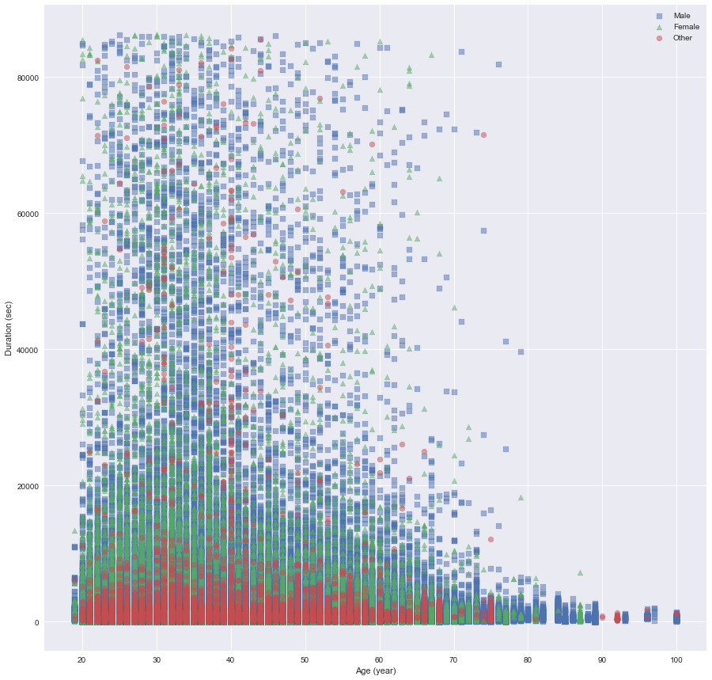

```python
plt.figure(figsize = [15,15])
gender_markers = [['Male', 's'],['Female', '^'],['Other', 'o']]

for gender, marker in gender_markers:
    df_gender = df_gobikeford[df_gobikeford['member_gender'] == gender]
    plt.scatter((df_gender['member_age']), df_gender['duration_sec'], marker = marker,alpha = .5)
plt.legend(['Male','Female','Other'])
plt.xlabel('Age (year)')
plt.ylabel('Duration (sec)')
plt.show()
```

For more details seperate member gender into different graphs.

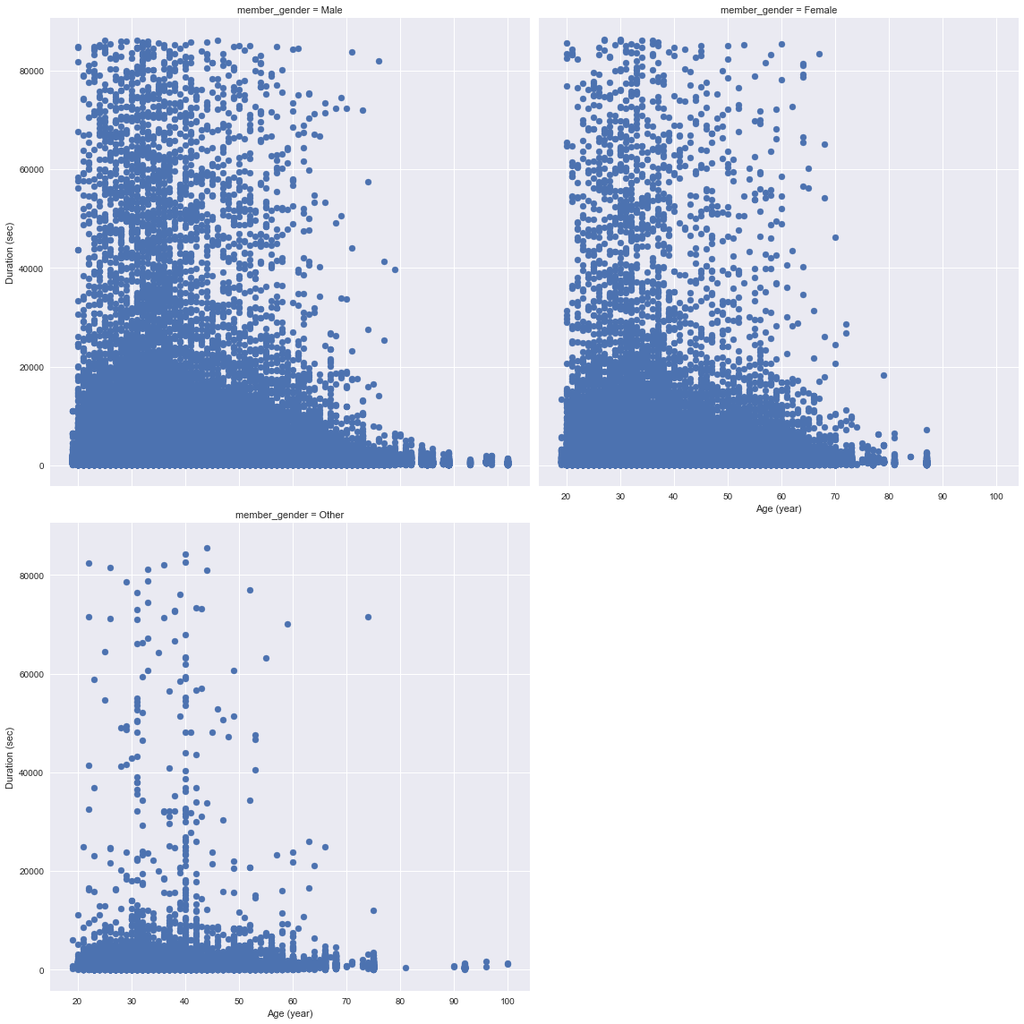

```python
plt.figure(figsize = [12,6])
user_types = sb.FacetGrid(data = df_gobikeford, col = 'member_gender', col_wrap = 2, height = 8)
user_types.map(plt.scatter, 'member_age', 'duration_sec')
user_types.set_xlabels('Age (year)')
user_types.set_ylabels('Duration (sec)')
plt.show()
```

All genders have same age distribution . Most of Ages distributed between 20 to 40.Females and other have long ride duration.

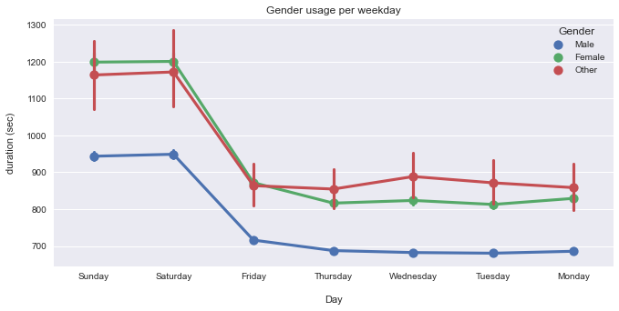

```python
plt.figure(figsize=(11,5))
ax = sb.pointplot(x='day_name', y='duration_sec', hue='member_gender', data=df_gobikeford)
plt.title('Gender usage per weekday', fontsize=12)
plt.xlabel('Day', labelpad=16)
plt.ylabel('duration (sec)', labelpad=12)
leg = ax.legend()
leg.set_title('Gender',prop={'size':12})
ax = plt.gca();
```

Female and others have long rides duration compared to males especially on sunday and saturday.

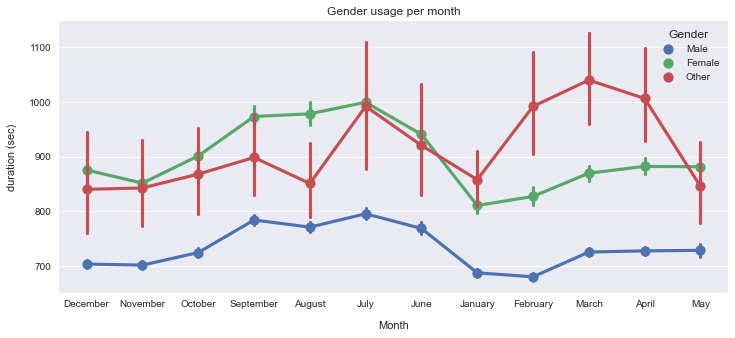

```python
plt.figure(figsize=(12,5))
ax = sb.pointplot(x='month_name', y='duration_sec', hue='member_gender', data=df_gobikeford)
plt.title('Gender usage per month', fontsize=12)
plt.xlabel('Month', labelpad=12)
plt.ylabel('duration (sec)', labelpad=12)
leg = ax.legend()
leg.set_title('Gender',prop={'size':12})
ax = plt.gca();
```

Females and others users has supersing performance as they have long trip duration compared to males from graph we can notice that males have lowest trip duration in January and February .

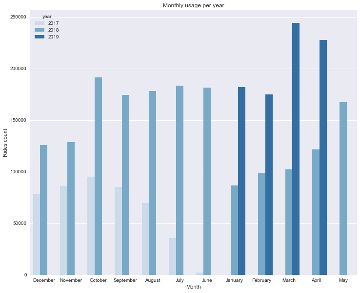

```python
plt.figure(figsize=[12,10])
sb.countplot(data=df_gobikeford ,x='month_name' ,hue='year',palette='Blues')
plt.title('Monthly usage per year')
plt.xlabel('Month')
plt.ylabel('Rides count')
```

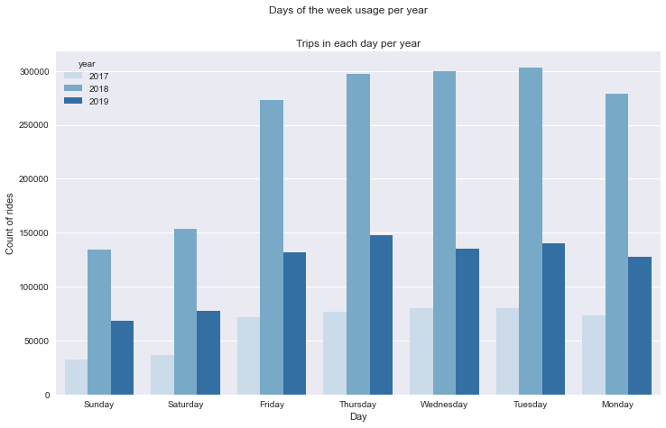

```python
plt.figure(figsize=[12,7])
plt.suptitle('Days of the week usage per year')
sb.countplot(data=df_gobikeford ,x='day_name' ,hue='year',palette='Blues')
plt.title('Trips in each day per year')
plt.xlabel('Day')
plt.ylabel('Count of rides')
```

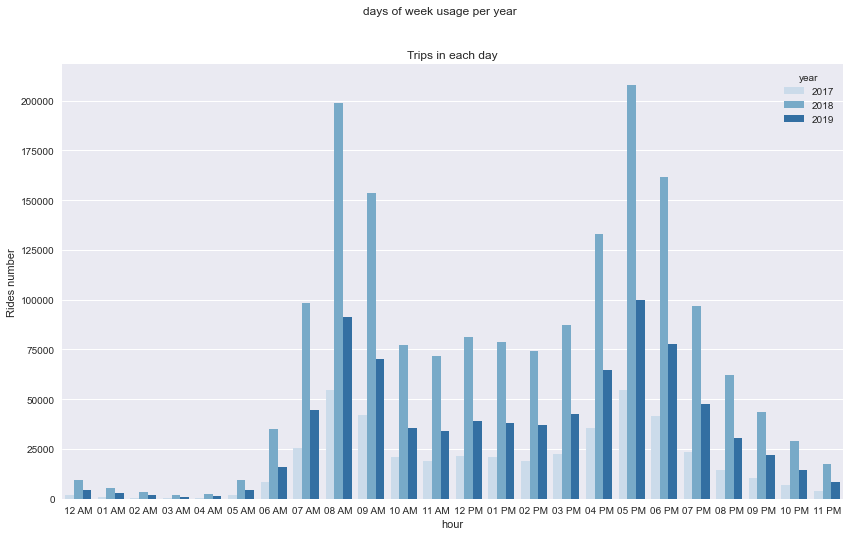

```python
plt.figure(figsize=[14,8])
plt.suptitle('days of week usage per year')
sb.countplot(data=df_gobikeford.sort_values(by='hour') ,x='start-hour',hue='year',palette='Blues')
plt.title('Trips in each day')
plt.xlabel('hour')
plt.ylabel('Rides number')
```

Through the years the peak hours fall between 8am to 6pm. It may be related to working hours.

### Talk about some of the relationships you observed in this part of the investigation. Were there features that strengthened each other in terms of looking at your feature(s) of interest?

Most of subscribes usage distribution are daily routine in moring and afternoon may be related to (working hours) however the customers using during weekends.The trip duration average is more higher for customer than subscribers.

### Were there any interesting or surprising interactions between features?

The Customer users are having higher trip duration than subscribers. Females and other users are more active compared to male users they are having higher trip durtion. The trips durations are stable for age range 20 to 40. It was surprising not only youth who uses bike but even adults older than 50 years old and also have long rides.

> At the end of your report, make sure that you export the notebook as an html file from the `File > Download as... > HTML` menu. Make sure you keep track of where the exported file goes, so you can put it in the same folder as this notebook for project submission. Also, make sure you remove all of the quote-formatted guide notes like this one before you finish your report!